# ANA515_Final Project

Thi Huyen Nguyen

12/12/2021

# Goal of the project: Use visualizations to analyze how time affected customer trips and how various users made trips from different bases.

# Installing Packages

install.packages(“tidyverse”) install.packages(“ggplot2”) install.packages(“ggthemes”) install.packages(“lubridate”) install.packages(“dplyr”) install.packages(“tidyr”) install.packages(“DT”) install.packages(“scales”)

# Calling installed packages

# Creating vector of colors to be implemented in our plots

#Using read.csv to import data from “C:/Users/16087/OneDrive/Documents”,

# Using summary to describe datasets

```
##   Date.Time              Lat             Lon             Base
##  Length:564516      Min.   :40.07   Min.   :-74.77   Length:564516
##  Class :character   1st Qu.:40.72   1st Qu.:-74.00   Class :character
##  Mode  :character   Median :40.74   Median :-73.98   Mode  :character
##                     Mean   :40.74   Mean   :-73.98
##                     3rd Qu.:40.76   3rd Qu.:-73.97
##                     Max.   :42.12   Max.   :-72.07
```

```
##   Date.Time              Lat             Lon             Base
##  Length:652435      Min.   :40.11   Min.   :-74.93   Length:652435
##  Class :character   1st Qu.:40.72   1st Qu.:-74.00   Class :character
##  Mode  :character   Median :40.74   Median :-73.98   Mode  :character
##                     Mean   :40.74   Mean   :-73.97
##                     3rd Qu.:40.76   3rd Qu.:-73.97
##                     Max.   :41.32   Max.   :-72.18
```

```
##   Date.Time              Lat             Lon             Base
##  Length:663844      Min.   :39.96   Min.   :-74.86   Length:663844
##  Class :character   1st Qu.:40.72   1st Qu.:-74.00   Class :character
##  Mode  :character   Median :40.74   Median :-73.98   Mode  :character
##                     Mean   :40.74   Mean   :-73.97
##                     3rd Qu.:40.76   3rd Qu.:-73.97
##                     Max.   :41.32   Max.   :-72.70
```

```
##   Date.Time              Lat             Lon             Base
##  Length:796121      Min.   :39.72   Min.   :-74.83   Length:796121
##  Class :character   1st Qu.:40.72   1st Qu.:-74.00   Class :character
##  Mode  :character   Median :40.74   Median :-73.98   Mode  :character
##                     Mean   :40.74   Mean   :-73.97
##                     3rd Qu.:40.76   3rd Qu.:-73.97
##                     Max.   :41.34   Max.   :-72.31
```

```
##   Date.Time              Lat             Lon             Base
##  Length:829275      Min.   :39.66   Min.   :-74.77   Length:829275
##  Class :character   1st Qu.:40.72   1st Qu.:-74.00   Class :character
##  Mode  :character   Median :40.74   Median :-73.98   Mode  :character
##                     Mean   :40.74   Mean   :-73.97
##                     3rd Qu.:40.76   3rd Qu.:-73.96
##                     Max.   :41.32   Max.   :-72.34
```

```
##   Date.Time              Lat             Lon             Base
##  Length:1028136     Min.   :39.99   Min.   :-74.77   Length:1028136
##  Class :character   1st Qu.:40.72   1st Qu.:-74.00   Class :character
##  Mode  :character   Median :40.74   Median :-73.98   Mode  :character
##                     Mean   :40.74   Mean   :-73.97
##                     3rd Qu.:40.76   3rd Qu.:-73.96
##                     Max.   :41.35   Max.   :-72.72
```

# Using rbind to bind dataframes

# Preparing data by Converting and Creating factors of time objects

#Plotting the trips by the hours in a day: Tnumber of trips are higher in the evening around 5:00 and 6:00 PM.

|  | hour | Total |
| --- | --- | --- |
| 1 | 0 | 103836 |
| 2 | 1 | 67227 |
| 3 | 2 | 45865 |
| 4 | 3 | 48287 |
| 5 | 4 | 55230 |
| 6 | 5 | 83939 |
| 7 | 6 | 143213 |
| 8 | 7 | 193094 |
| 9 | 8 | 190504 |
| 10 | 9 | 159967 |

[output cut: 14 more lines]

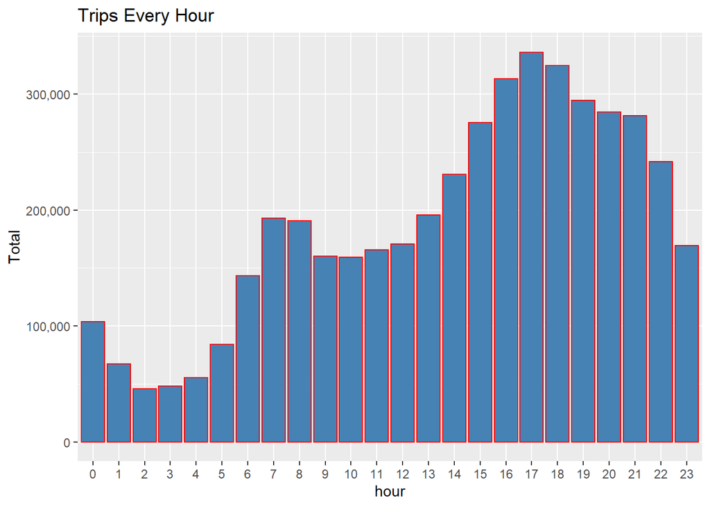

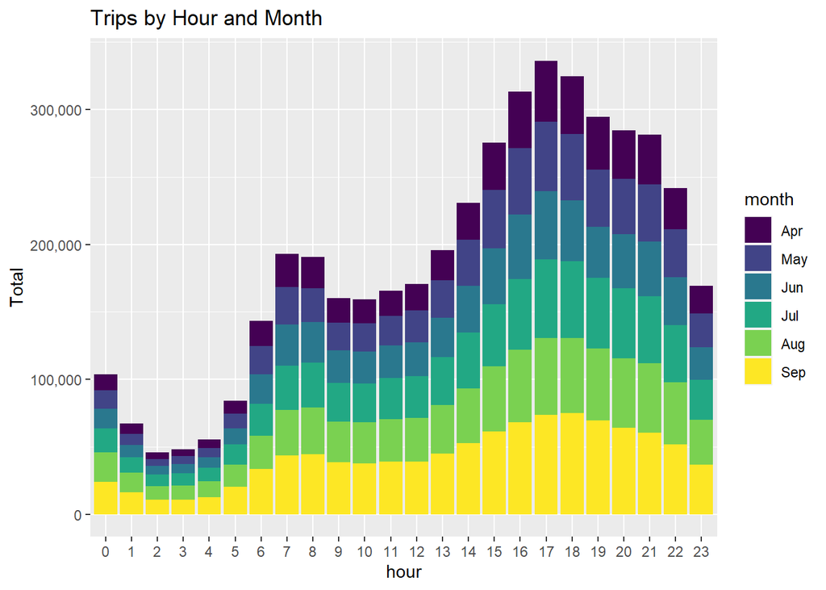

# Plotting data by trips during every day of the month: number of trips are higher in the day 30th of the month.

|  | day | Total |
| --- | --- | --- |
| 1 | 1 | 127430 |
| 2 | 2 | 143201 |
| 3 | 3 | 142983 |
| 4 | 4 | 140923 |
| 5 | 5 | 147054 |
| 6 | 6 | 139886 |
| 7 | 7 | 143503 |
| 8 | 8 | 145984 |
| 9 | 9 | 155135 |
| 10 | 10 | 152500 |

[output cut: 21 more lines]

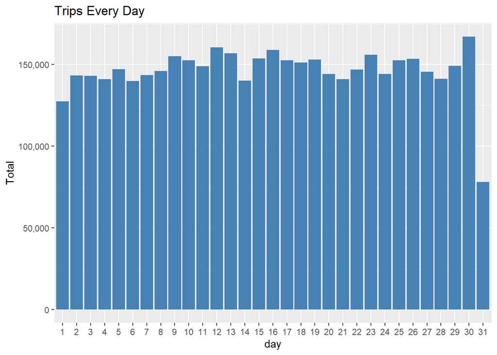

# Plotting data by trips by day and month: number of trips are higher in day 30 and September

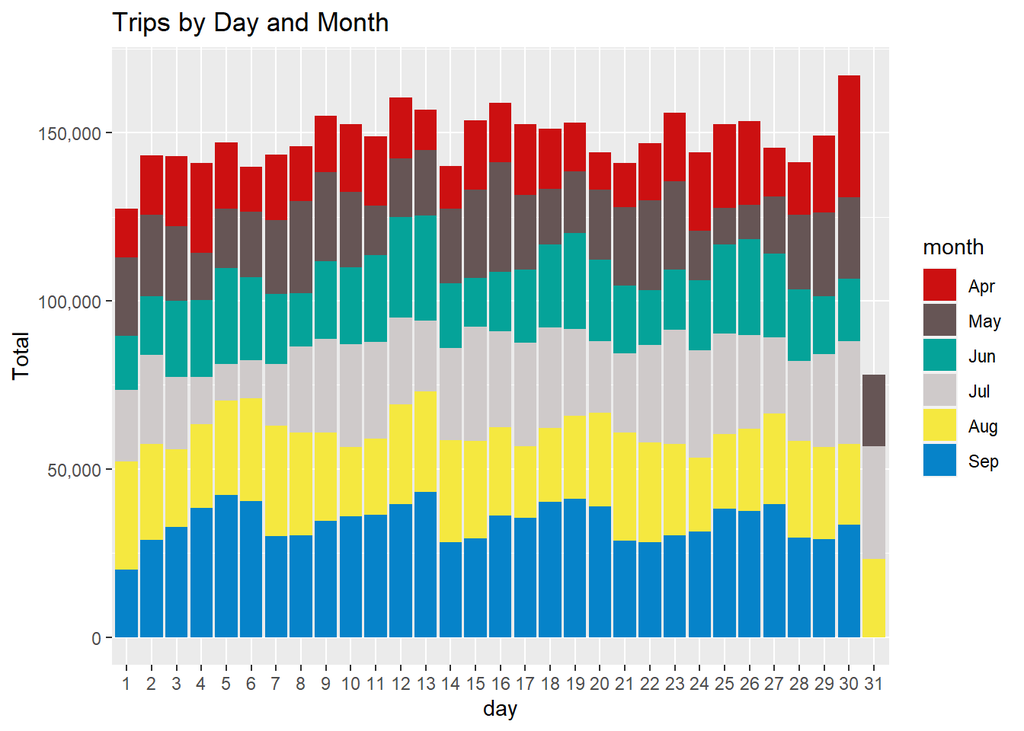

# Ploting Number of Trips taking place during months in a year: September is the most busy month of the year in the data

|  | month | Total |
| --- | --- | --- |
| 1 | Apr | 564516 |
| 2 | May | 652435 |
| 3 | Jun | 663844 |
| 4 | Jul | 796121 |
| 5 | Aug | 829275 |
| 6 | Sep | 1028136 |

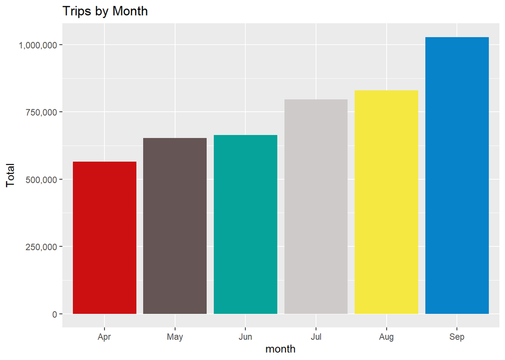

# Ploting trip volume by Base: number of trips are higher in Base 02617

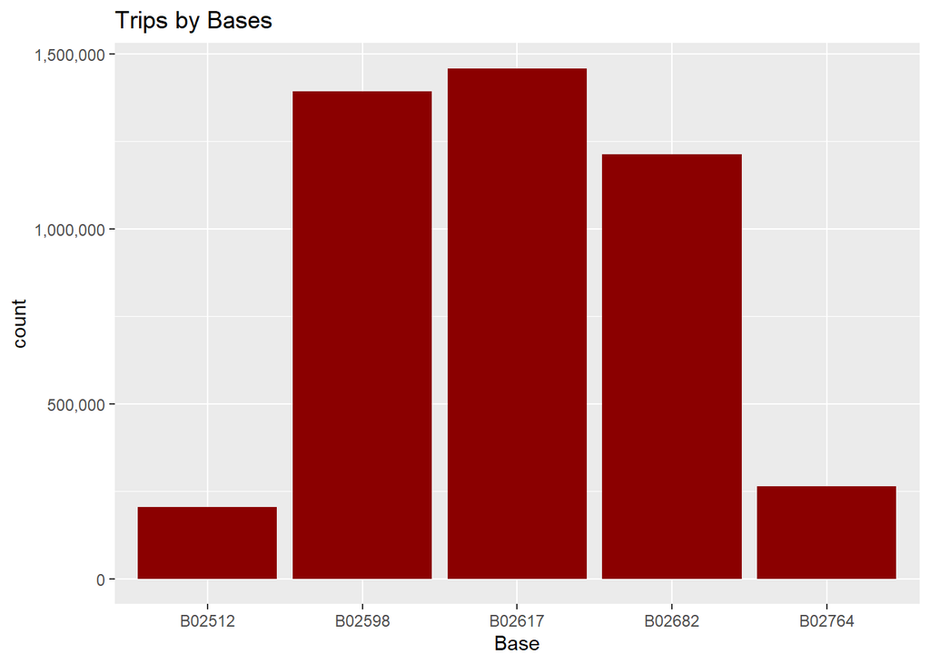

# Ploting trips by Bases and Month: number of trips are higher Base 02617 and September

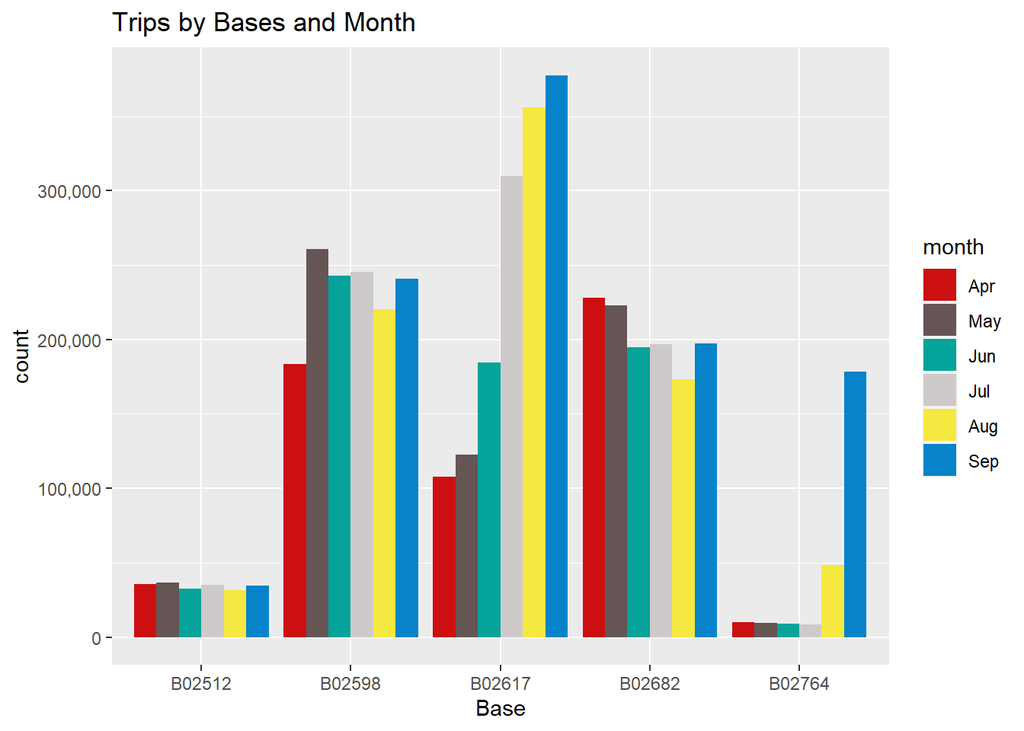